# 1US0 TYR Ring_0_0.2_10_Difference

11/51

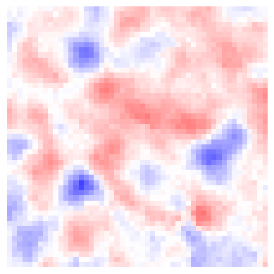

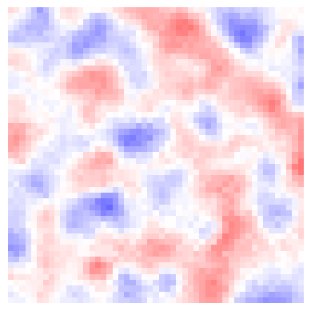

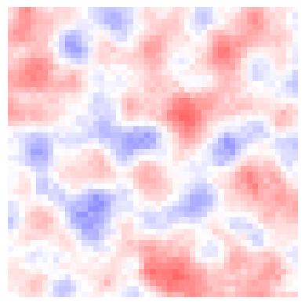

12/51

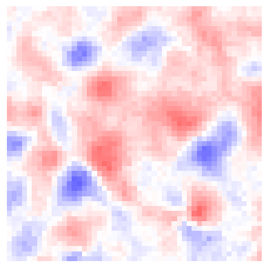

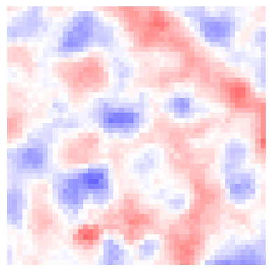

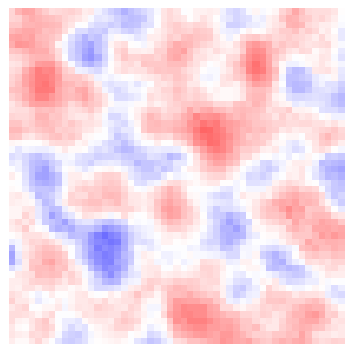

13/51

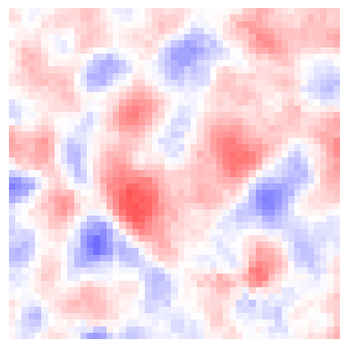

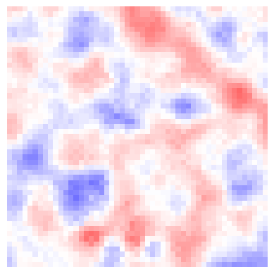

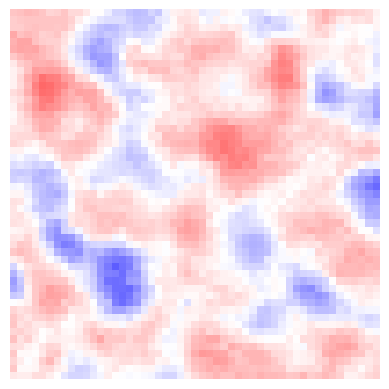

14/51

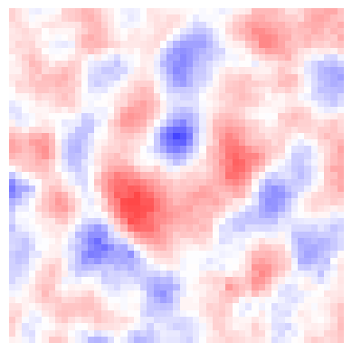

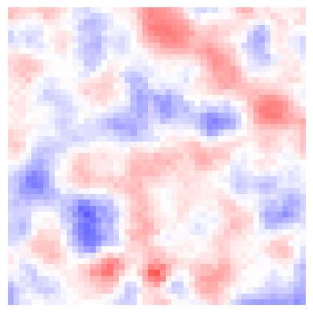

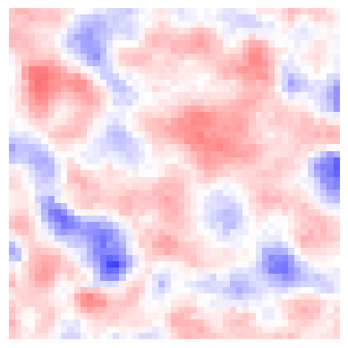

15/51

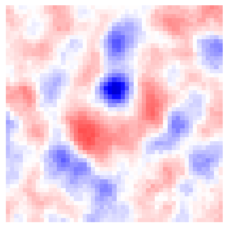

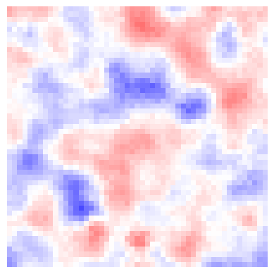

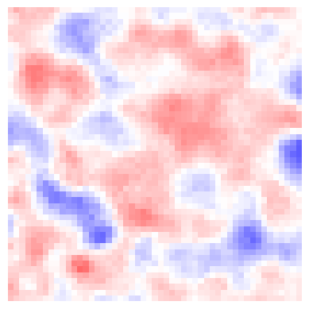

16/51

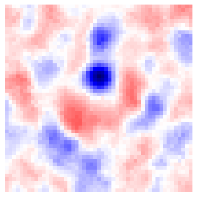

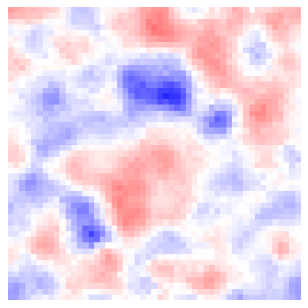

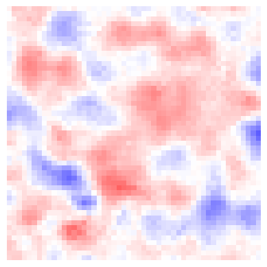

17/51

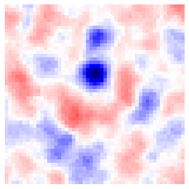

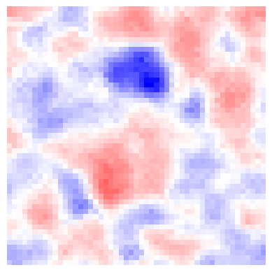

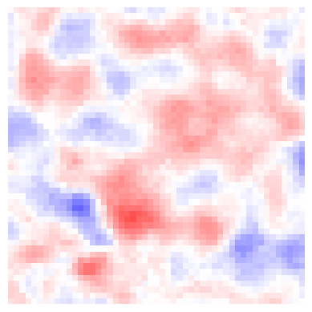

18/51

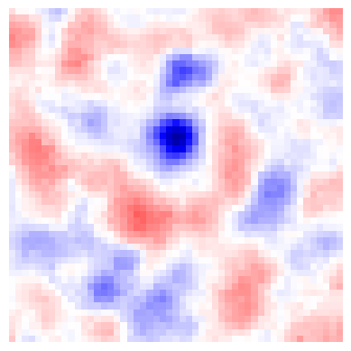

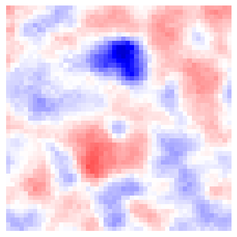

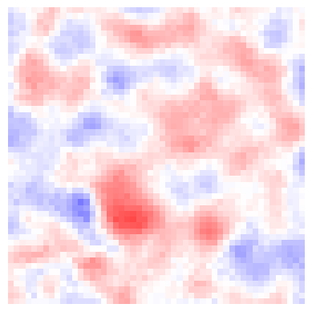

19/51